# Chapter 8 Problems

# Question 7

In the lab, we applied random forests to the Boston data using mtry = 6 and using ntree = 25 and ntree = 500. Create a plot displaying the test error resulting from random forests on this data set for a more comprehensive range of values for mtry and ntree. You can model your plot after Figure 8.10. Describe the results obtained

```r
library(randomForest)
library(MASS)
test.err = double(13)
dim(Boston)
```

```
## [1] 506  14
```

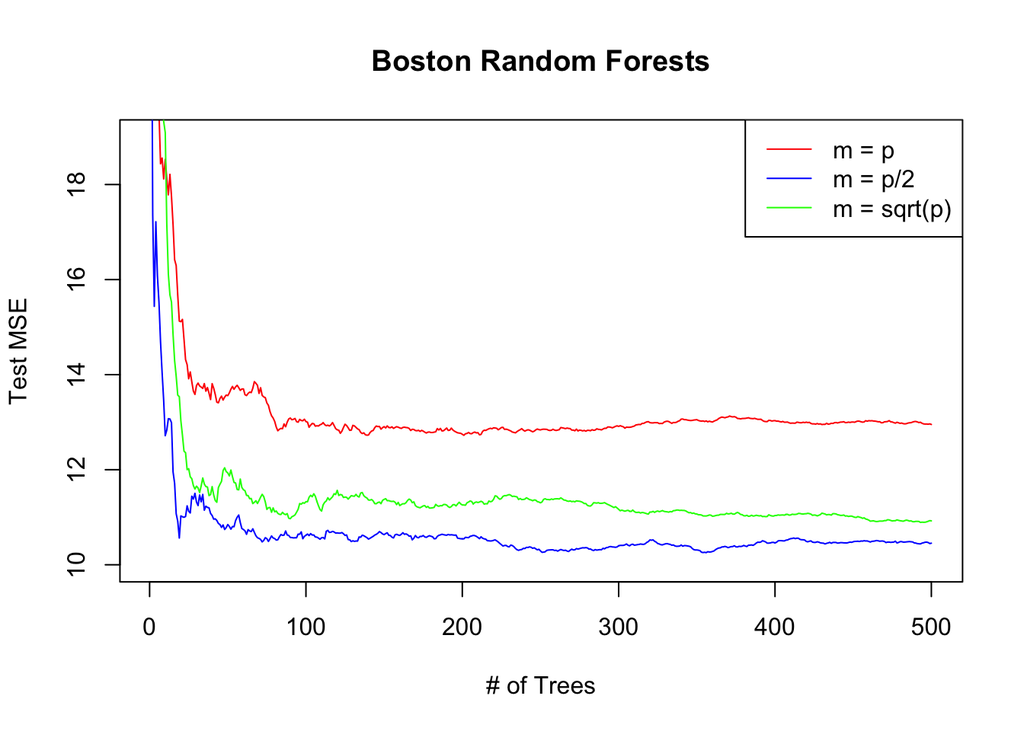

```r
train = sample(1:nrow(Boston), 300)
attach(Boston)
set.seed(10)
x.train = Boston[train, -14]
x.test = Boston[-train, -14]
y.train = Boston[train, "medv"]
y.test = Boston[-train, "medv"]

rf.boston1 = randomForest(x.train, y = y.train, xtest = x.test, ytest = y.test, mtry = dim(Boston)[2] - 1, ntree = 500)
rf.boston2 = randomForest(x.train, y = y.train, xtest = x.test, ytest = y.test, mtry = (dim(Boston)[2] - 1)/2, ntree = 500)
rf.boston3 = randomForest(x.train, y = y.train, xtest = x.test, ytest = y.test, mtry = sqrt(dim(Boston)[2] - 1), ntree = 500)
plot(1:500, rf.boston1$mse, ylim = c(10,19), xlab = "# of Trees", ylab = "Test MSE", main = "Boston Random Forests", type = "l", col = "red")
lines(1:500, rf.boston2$mse, col = "blue")
lines(1:500, rf.boston3$mse, col = "green")
legend("topright", c("m = p", "m = p/2", "m = sqrt(p)"), col = c("red", "blue", "green"), cex = 1, lty = 1)
```

# Question 8

In the lab, a classification tree was applied to the Carseats data set after converting Sales into a qualitative response variable. Now we will seek to predict Sales using regression trees and related approaches, treating the response as a quantitative variable.

## (a) Split the data set into a training set and a test set.

```r
detach(Boston)
library(ISLR)
library(tree)
set.seed(14)
dim(Carseats)
```

```
## [1] 400  11
```

```r
train = sample(1:nrow(Carseats), 250)
test = Carseats[-train,]
colnames(Carseats)
```

```
##  [1] "Sales"       "CompPrice"   "Income"      "Advertising" "Population"
##  [6] "Price"       "ShelveLoc"   "Age"         "Education"   "Urban"
## [11] "US"
```

```r
x.train = Carseats[train, -1]
x.test = Carseats[-train, -1]
y.train = Carseats[train, 1]
y.test = Carseats[-train, 1]
```

## (b) Fit a regression tree to the training set. Plot the tree, and interpret the results. What test MSE do you obtain?

```r
tree.carseats = tree(Sales ~ ., data = Carseats, subset = train)
summary(tree.carseats)
```

```
##
## Regression tree:
## tree(formula = Sales ~ ., data = Carseats, subset = train)
## Variables actually used in tree construction:
## [1] "ShelveLoc"   "Price"       "Age"         "Income"      "CompPrice"
## [6] "Advertising" "US"
## Number of terminal nodes:  18
## Residual mean deviance:  2.259 = 524 / 232
## Distribution of residuals:
##     Min.  1st Qu.   Median     Mean  3rd Qu.     Max.
## -3.76500 -1.02700 -0.01471  0.00000  0.96890  3.93100
```

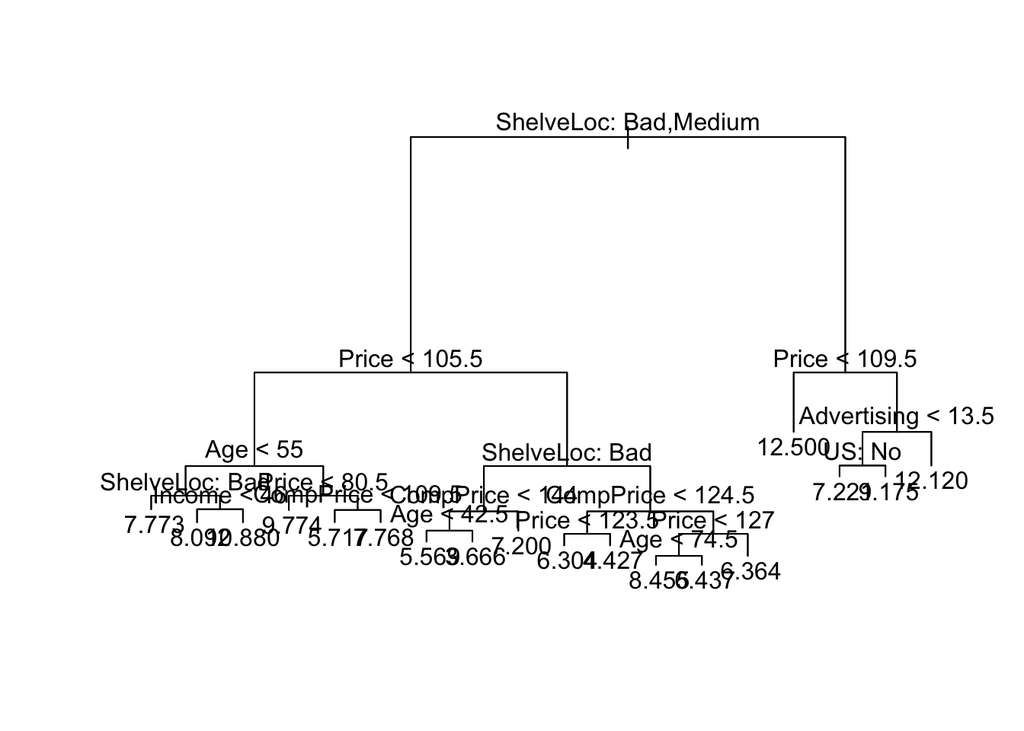

```r
plot(tree.carseats);text(tree.carseats, pretty = 0)
```

```r
names(tree.carseats)
```

```
## [1] "frame"   "where"   "terms"   "call"    "y"       "weights"
```

```r
tree.carseats
```

```
## node), split, n, deviance, yval
##       * denotes terminal node
##
##  1) root 250 1985.000  7.596
##    2) ShelveLoc: Bad,Medium 197 1082.000  6.845
##      4) Price < 105.5 60  273.900  8.399
##        8) Age < 55 27  104.300  9.558
##         16) ShelveLoc: Bad 7    8.741  7.773 *
##         17) ShelveLoc: Medium 20   65.450 10.180
##           34) Income < 46 5    7.501  8.092 *
##           35) Income > 46 15   28.800 10.880 *
##        9) Age > 55 33  103.600  7.451
##         18) Price < 80.5 5    5.197  9.774 *
##         19) Price > 80.5 28   66.580  7.036
##           38) CompPrice < 109.5 10   15.970  5.717 *
##           39) CompPrice > 109.5 18   23.560  7.768 *
##      5) Price > 105.5 137  599.400  6.164
##       10) ShelveLoc: Bad 37  137.100  4.754
##         20) CompPrice < 144 31   79.420  4.280
##           40) Age < 42.5 10   29.470  5.569 *
##           41) Age > 42.5 21   25.420  3.666 *
##         21) CompPrice > 144 6   14.840  7.200 *
##       11) ShelveLoc: Medium 100  361.400  6.686
##         22) CompPrice < 124.5 33   89.640  5.678
##           44) Price < 123.5 22   47.360  6.304 *
##           45) Price > 123.5 11   16.460  4.427 *
##         23) CompPrice > 124.5 67  221.800  7.182
##           46) Price < 127 32   74.850  8.077
##             92) Age < 74.5 26   43.240  8.455 *
##             93) Age > 74.5 6   11.750  6.437 *
##           47) Price > 127 35   97.890  6.364 *
##    3) ShelveLoc: Good 53  379.100 10.390
##      6) Price < 109.5 19   65.300 12.500 *
##      7) Price > 109.5 34  181.500  9.207
##       14) Advertising < 13.5 27   97.900  8.451
##         28) US: No 10   37.730  7.221 *
##         29) US: Yes 17   36.140  9.175 *
##       15) Advertising > 13.5 7    8.642 12.120 *
```

```r
pred = predict(tree.carseats, newdata = Carseats[-train,])
mean((pred - y.test)^2)
```

```
## [1] 4.155503
```

3. Use cross-validation in order to determine the optimal level of tree complexity. Does pruning the tree improve the test MSE?

```r
set.seed(4)
cv.carseats = cv.tree(tree.carseats)
cv.carseats
```

```
## $size
##  [1] 18 17 16 15 14 13 12 11 10  9  8  7  6  5  4  3  2  1
##
## $dev
##  [1] 1129.737 1158.908 1114.800 1117.274 1106.060 1080.599 1065.305 1065.305
##  [9] 1078.468 1139.099 1160.774 1161.552 1170.675 1182.060 1296.293 1327.205
## [17] 1488.559 1992.974
##
## $k
##  [1]      -Inf  19.86671  24.03275  24.52721  25.81876  27.05123  29.14854
##  [8]  30.11964  31.81058  42.86244  49.02862  50.01696  65.95974  74.94250
## [15] 100.84843 132.29425 208.42748 524.37332
##
## $method
## [1] "deviance"
##
## attr(,"class")
## [1] "prune"         "tree.sequence"
```

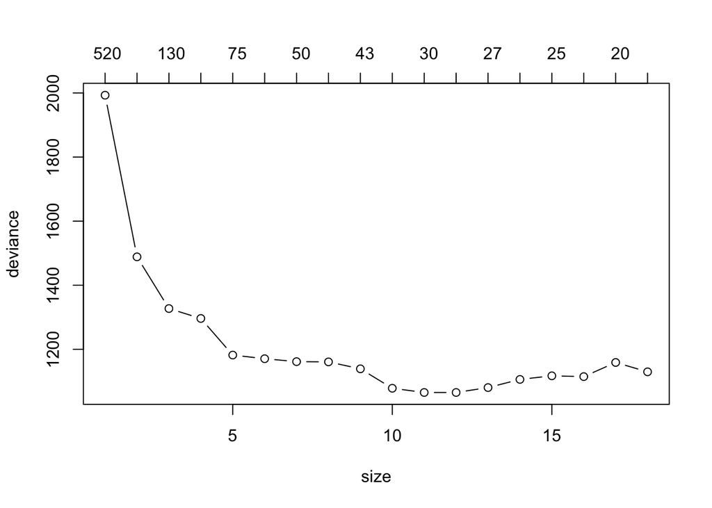

```r
plot(cv.carseats, type = "b")
```

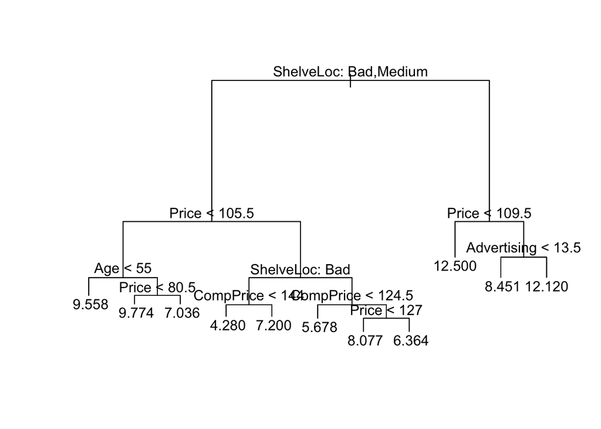

```r
prune.carseats = prune.tree(tree.carseats, best = 11)
plot(prune.carseats); text(prune.carseats, pretty = 0)
```

```r
tree.pred = predict(prune.carseats, newdata = Carseats[-train,])
mean((tree.pred - y.test)^2)
```

```
## [1] 4.207619
```

Pruning the tree down to 11 terminal nodes increases the Test MSE slightly from 4.1555 to 4.2076.

4. Use the bagging approach in order to analyze this data. What test MSE do you obtain? Use the importance() function to determine which variables are most important. ———————-

```r
library(randomForest)
set.seed(1)
bag.carseats = randomForest(Sales ~ ., data = Carseats[train,], mtry = 10, importance = TRUE)
bag.carseats
```

```
##
## Call:
##  randomForest(formula = Sales ~ ., data = Carseats[train, ], mtry = 10,      importance = TRUE)
##                Type of random forest: regression
##                      Number of trees: 500
## No. of variables tried at each split: 10
##
##           Mean of squared residuals: 2.692799
##                     % Var explained: 66.09
```

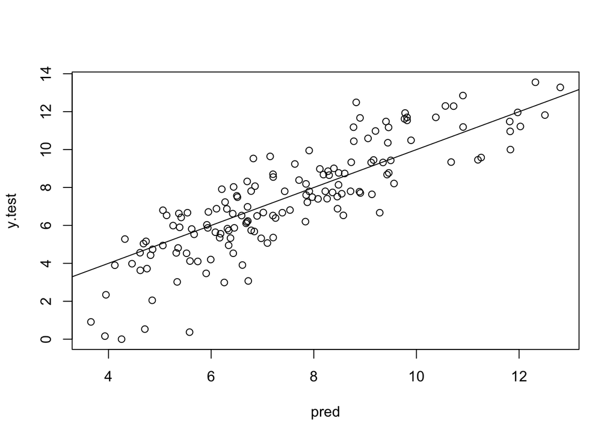

```r
pred = predict(bag.carseats, newdata = Carseats[-train,])
plot(pred, y.test)
abline(0, 1)
```

```r
mean((pred - y.test)^2)
```

```
## [1] 2.276181
```

```r
importance(bag.carseats)
```

```
##                %IncMSE IncNodePurity
## CompPrice   28.4400289    194.520857
## Income       7.5986657     96.513656
## Advertising 20.0197855    133.271257
## Population  -2.9149884     62.775972
## Price       63.5576291    549.365815
## ShelveLoc   60.5834013    626.457265
## Age         21.6534036    196.443781
## Education    0.4414308     52.314749
## Urban       -0.9789337      7.520592
## US           4.2817716     10.403873
```

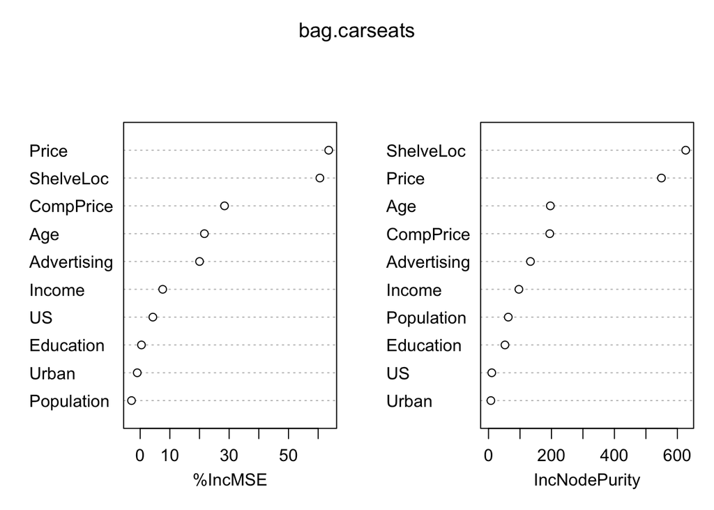

```r
varImpPlot(bag.carseats)
```

Price and ShelveLoc are the two most important variables in predicting the Sales of the Carseats data.

5. Use random forests to analyze this data. What test MSE do you obtain? Use the importance() function to determine which variables are most important. Describe the effect of m, the number of variables considered at each split, on the error rate obtained. ————————

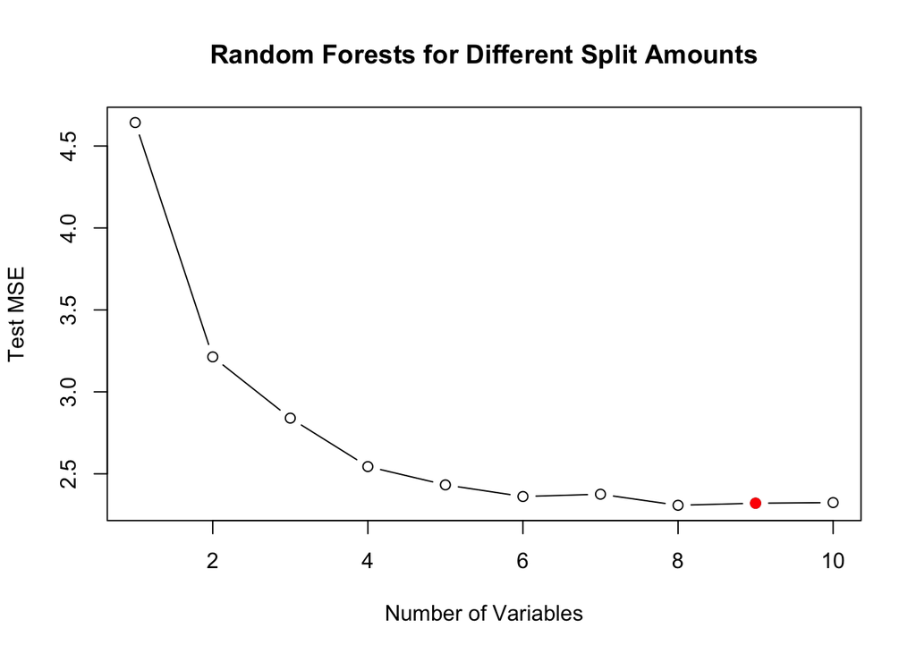

```r
test.err = rep(NA, 10)

for (mtry in 1:10){
  fit = randomForest(Sales ~ ., data = Carseats[train,], mtry = mtry, importance = TRUE)
  pred = predict(fit, newdata = Carseats[-train,])
  test.err[mtry] = mean((pred - y.test)^2)
}

plot(1:10, test.err, type = "b", xlab = "Number of Variables", ylab = "Test MSE", main = "Random Forests for Different Split Amounts")
points(9, test.err[9], col = "red", cex = 1, pch = 19)
```

# Question 9

This problem involves the OJ data set which is part of the ISLR2 package.

## (a) Create a training set containing a random sample of 800 observations, and a test set containing the remaining observations

```r
library(ISLR2)
dim(OJ)
```

```
## [1] 1070   18
```

```r
train = sample(1:nrow(OJ), 800)
OJ.train = OJ[train,]
OJ.test = OJ[-train,]
```

## (b) Fit a tree to the training data, with Purchase as the response and the other variables as predictors. Use the summary() function to produce summary statistics about the tree, and describe the results obtained. What is the training error rate? How many terminal nodes does the tree have?

```r
oj.tree = tree(Purchase ~ ., data = OJ.train)
summary(oj.tree)
```

```
##
## Classification tree:
## tree(formula = Purchase ~ ., data = OJ.train)
## Variables actually used in tree construction:
## [1] "LoyalCH"       "PriceDiff"     "ListPriceDiff" "PctDiscMM"
## Number of terminal nodes:  8
## Residual mean deviance:  0.7178 = 568.5 / 792
## Misclassification error rate: 0.1588 = 127 / 800
```

## (c) Type in the name of the tree object in order to get a detailed text output. Pick one of the terminal nodes, and interpret the information displayed.

```r
oj.tree
```

```
## node), split, n, deviance, yval, (yprob)
##       * denotes terminal node
##
##  1) root 800 1070.00 CH ( 0.61000 0.39000 )
##    2) LoyalCH < 0.5036 352  414.50 MM ( 0.27557 0.72443 )
##      4) LoyalCH < 0.261626 166  114.00 MM ( 0.10843 0.89157 )
##        8) LoyalCH < 0.0608385 72   10.54 MM ( 0.01389 0.98611 ) *
##        9) LoyalCH > 0.0608385 94   88.86 MM ( 0.18085 0.81915 ) *
##      5) LoyalCH > 0.261626 186  253.60 MM ( 0.42473 0.57527 )
##       10) PriceDiff < 0.05 73   76.78 MM ( 0.21918 0.78082 ) *
##       11) PriceDiff > 0.05 113  155.20 CH ( 0.55752 0.44248 ) *
##    3) LoyalCH > 0.5036 448  341.50 CH ( 0.87277 0.12723 )
##      6) LoyalCH < 0.764879 180  208.80 CH ( 0.73333 0.26667 )
##       12) ListPriceDiff < 0.235 71   98.41 MM ( 0.49296 0.50704 )
##         24) PctDiscMM < 0.196196 53   70.25 CH ( 0.62264 0.37736 ) *
##         25) PctDiscMM > 0.196196 18   12.56 MM ( 0.11111 0.88889 ) *
##       13) ListPriceDiff > 0.235 109   75.58 CH ( 0.88991 0.11009 ) *
##      7) LoyalCH > 0.764879 268   78.78 CH ( 0.96642 0.03358 ) *
```

## (d) Create a plot of the tree, and interpret the results.

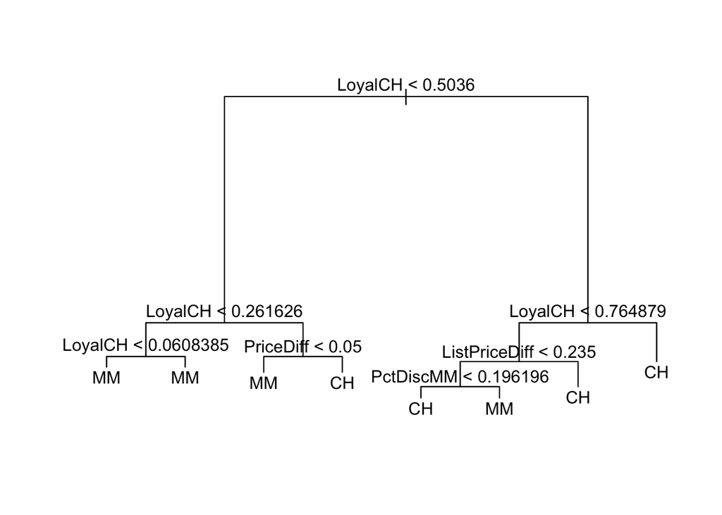

```r
plot(oj.tree); text(oj.tree, pretty = 0)
```

LoyalCH was the most important variable in predicting whether a customer purchased Minute Maid (MM) or Citrus Hill (CH) orange juice.

## (e) Predict the response on the test data, and produce a confusion matrix comparing the test labels to the predicted test labels. What is the test error rate?

```r
pred = predict(oj.tree, newdata = OJ.test, type = "class")
table(pred, OJ.test$Purchase)
```

[output not shown]

```r
(39 + 19) / 270
```

```
## [1] 0.2148148
```

## (f) Apply the cv.tree() function to the training set in order to determine the optimal tree size.

```r
cv.oj = cv.tree(oj.tree)
```

## (g) Produce a plot with tree size on the x-axis and cross-validated classification error rate on the y-axis.

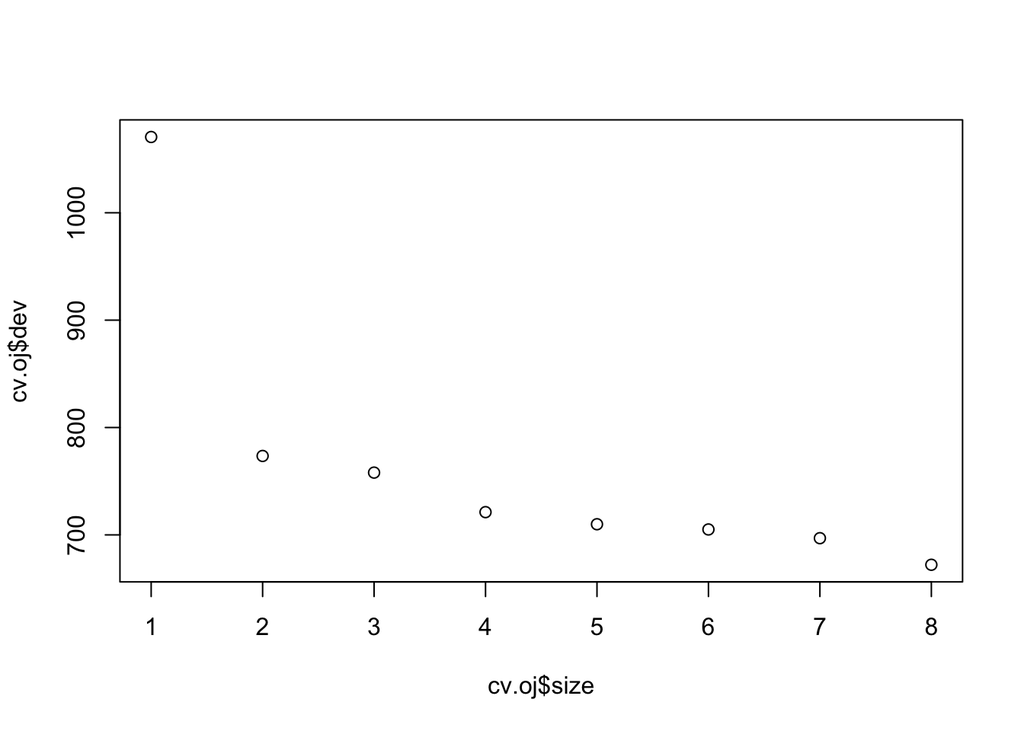

```r
plot(cv.oj$size, cv.oj$dev)
```

## (h) Which tree size corresponds to the lowest cross-validated classification error rate?

```r
min(cv.oj$dev)
```

```
## [1] 672.1787
```

```r
cv.oj$size[which.min(cv.oj$dev)]
```

```
## [1] 8
```

## (i) Produce a pruned tree corresponding to the optimal tree size obtained using cross-validation. If cross-validation does not lead to selection of a pruned tree, then create a pruned tree with five terminal nodes.

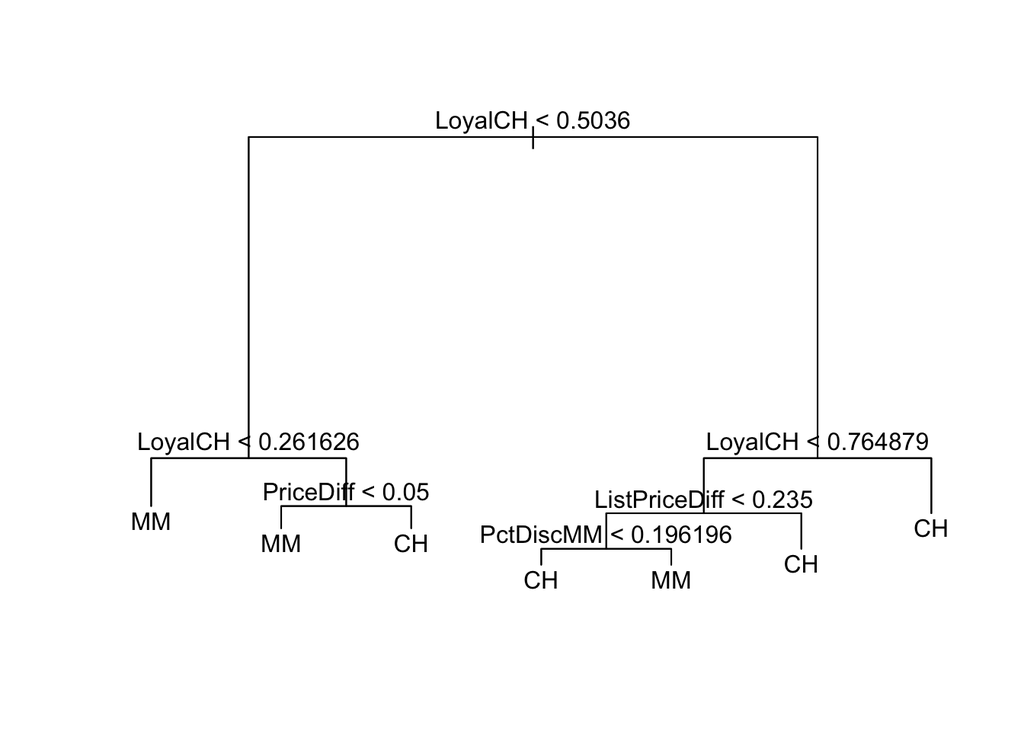

```r
prune.oj = prune.misclass(oj.tree, best = 6)
plot(prune.oj); text(prune.oj, pretty = 0)
```

## (j) Compare the training error rates between the pruned and unpruned trees. Which is higher?

```r
summary(prune.oj)
```

```
##
## Classification tree:
## snip.tree(tree = oj.tree, nodes = 4L)
## Variables actually used in tree construction:
## [1] "LoyalCH"       "PriceDiff"     "ListPriceDiff" "PctDiscMM"
## Number of terminal nodes:  7
## Residual mean deviance:  0.7353 = 583.1 / 793
## Misclassification error rate: 0.1588 = 127 / 800
```

11. Compare the test error rates between the pruned and unpruned trees. Which is higher? ————–

```r
pred.prune = predict(prune.oj, OJ.test, type = "class")
table(pred.prune, OJ.test$Purchase)
```

[output not shown]

```r
(39 + 19) / 270
```

```
## [1] 0.2148148
```